# Candy Example

Lu Vy, Nick Weaver, & Chandler Zachary

November 14, 2018

## Real World Data 2: Choosing Optimal Clusters

Often in clustering analysis, one will know the number of clusters to use in the algorithm prior to the analysis. This may be from domain-specific knowledge or predetermined by business managers. However, one may need to determine the number of clusters without such prior knowledge. In fact, it may be more interesting to use the algorithm to uncover the optimal number of clusters rather than assume it beforehand. Making such determination can be done by executing the algorithm multiple times for different numbers of clusters and constructing a scree plot, which helps identify the optimal tradeoff between the number of clusters and within-cluster sum of squares. This final example demonstrates how such a plot is constructed.

Our example uses the candy data set from 538.com’s story “The Ultimate Halloween Candy Power Ranking.” This data set uses binary values to indicate various characteristics of 85 different halloween candies and records the sugar content and price of each candy. These candies were pre-selected and then ranked by individuals in an online contest. The results were analyzed to reveal which characteristics made some candies better than others. This data set is illustrative for two reasons. First, there are 11 predictors, and 11 dimensions is difficult to visualize. Second, it might seem difficult at first to decide how many and which characteristics of a candy make it a good seller.

First, load the data.

```r
candy = read.csv("candydata.csv.txt")
str(candy)
```

```
## 'data.frame':    85 obs. of  13 variables:
##  $ ï..competitorname: Factor w/ 85 levels "100 Grand","3 Musketeers",..: 1 2 45 46 3 4 5 6 7 8 ...
##  $ chocolate        : int  1 1 0 0 0 1 1 0 0 0 ...
##  $ fruity           : int  0 0 0 0 1 0 0 0 0 1 ...
##  $ caramel          : int  1 0 0 0 0 0 1 0 0 1 ...
##  $ peanutyalmondy   : int  0 0 0 0 0 1 1 1 0 0 ...
##  $ nougat           : int  0 1 0 0 0 0 1 0 0 0 ...
##  $ crispedricewafer : int  1 0 0 0 0 0 0 0 0 0 ...
##  $ hard             : int  0 0 0 0 0 0 0 0 0 0 ...
##  $ bar              : int  1 1 0 0 0 1 1 0 0 0 ...
##  $ pluribus         : int  0 0 0 0 0 0 0 1 1 0 ...
##  $ sugarpercent     : num  0.732 0.604 0.011 0.011 0.906 ...
##  $ pricepercent     : num  0.86 0.511 0.116 0.511 0.511 ...
##  $ winpercent       : num  67 67.6 32.3 46.1 52.3 ...
```

```r
dim(candy)
```

```
## [1] 85 13
```

```r
head(candy)
```

```
##   ï..competitorname chocolate fruity caramel peanutyalmondy nougat
## 1         100 Grand         1      0       1              0      0
## 2      3 Musketeers         1      0       0              0      1
## 3          One dime         0      0       0              0      0
## 4       One quarter         0      0       0              0      0
## 5         Air Heads         0      1       0              0      0
## 6        Almond Joy         1      0       0              1      0
##   crispedricewafer hard bar pluribus sugarpercent pricepercent winpercent
## 1                1    0   1        0        0.732        0.860   66.97173
## 2                0    0   1        0        0.604        0.511   67.60294
## 3                0    0   0        0        0.011        0.116   32.26109
## 4                0    0   0        0        0.011        0.511   46.11650
## 5                0    0   0        0        0.906        0.511   52.34146
## 6                0    0   1        0        0.465        0.767   50.34755
```

Now, imagine a candy manufacturer asking such questions as “Which characteristics should we focus on to make the best-selling candy? Should it be chocolate mixed with another ingredient? Should it be fruity or gummy?”

To arrive at answers to these questions, we execute the k-means algorithm as described above. There are 11 predictors after removing the name and the win percentage, so we execute the algorithm 11 times.

```r
# Initialize total within-cluster sum of squares: wss
wss = numeric(0)

# Execute algorithm for 1 to 11 cluster centers and record wss
for (i in 1:11) {
  km.out = kmeans(candy[, -c(1,13)], centers = i, nstart = 30)
  # Save total within sum of squares to wss variable
  wss[i] = km.out$tot.withinss
}
```

Now, we construct the scree plot.

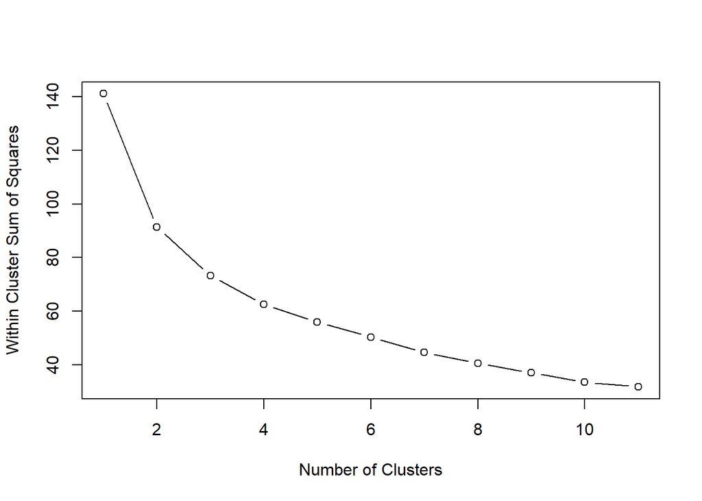

```r
# Plot total within-cluster sum of squares against number of clusters
plot(1:11, wss, type = "b",
     xlab = "Number of Clusters",
     ylab = "Within Cluster Sum of Squares")
```

When reviewing a scree plot, we look for the elbow point. This is the point where the total within-cluster sum of squares decreases at a slower rate than the increase in the number of clusters, and it indicates the optimal tradeoff between the number of clusters and the within-cluster sum of squares. This point is not always obvious and may require some subjective judgement to identify when the slopes of lines are not clearly different before and after the optimal point.

In our example, the elbow point seems to be at two clusters, but some may think it’s at three. It’s not easy to identify whether the slope is greater than or less than one between 2 and 3 clusters. When it’s unclear, one should rely on domain-specific knowledge to inform the decision. In either case, the choice of k is less arbitrary.

To help the candy maker, we’d take this information and review different visualizations to see how the characteristics separate into two or three clusters and identify what might be the best predictors to focus on for making candy.

Now, we reproduce the same example in Python.

```python
import os
from math import *
import numpy as np
import pandas as pd
import matplotlib.pyplot as plt
from scipy.stats import norm
from scipy.spatial.distance import cdist
from sklearn.cluster import KMeans
```

```python
os.chdir('E:/MATH/MATH 6388 -- Machine Learning/Projects/Project 3')
data = pd.read_csv('candydata.csv.txt')
data.info()
```

```
## <class 'pandas.core.frame.DataFrame'>
## RangeIndex: 85 entries, 0 to 84
## Data columns (total 13 columns):
## competitorname      85 non-null object
## chocolate           85 non-null int64
## fruity              85 non-null int64
## caramel             85 non-null int64
## peanutyalmondy      85 non-null int64
## nougat              85 non-null int64
## crispedricewafer    85 non-null int64
## hard                85 non-null int64
## bar                 85 non-null int64
## pluribus            85 non-null int64
## sugarpercent        85 non-null float64
## pricepercent        85 non-null float64
## winpercent          85 non-null float64
## dtypes: float64(3), int64(9), object(1)
## memory usage: 8.7+ KB
```

```python
print(data.head())
```

```
##   competitorname  chocolate     ...      pricepercent  winpercent
## 0      100 Grand          1     ...             0.860   66.971725
## 1   3 Musketeers          1     ...             0.511   67.602936
## 2       One dime          0     ...             0.116   32.261086
## 3    One quarter          0     ...             0.511   46.116505
## 4      Air Heads          0     ...             0.511   52.341465
##
## [5 rows x 13 columns]
```

```python
print(data.tail())
```

```
##                 competitorname  chocolate     ...      pricepercent  winpercent
## 80                   Twizzlers          0     ...             0.116   45.466282
## 81                    Warheads          0     ...             0.116   39.011898
## 82        WelchÕs Fruit Snacks          0     ...             0.313   44.375519
## 83  WertherÕs Original Caramel          0     ...             0.267   41.904308
## 84                    Whoppers          1     ...             0.848   49.524113
##
## [5 rows x 13 columns]
```

```python
np.random.seed(0)
predictors = data[['chocolate', 'fruity', 'caramel', 'peanutyalmondy', 'nougat', \
                   'crispedricewafer', 'hard', 'bar', 'pluribus', 'sugarpercent', \
                   'pricepercent']]
```

Just as before, we execute the algorithm for three clusters.

```python
kmCandyCluster = KMeans(n_clusters = 3, n_init = 30)
kmCandyCluster.fit(predictors)
```

Now, we iteratively execute the algorithm to determine the optimal number of clusters and generate the scree plot. You’ll notice that the optimal number of clusters again appears to be either two or three. Someone might even think it’s four.

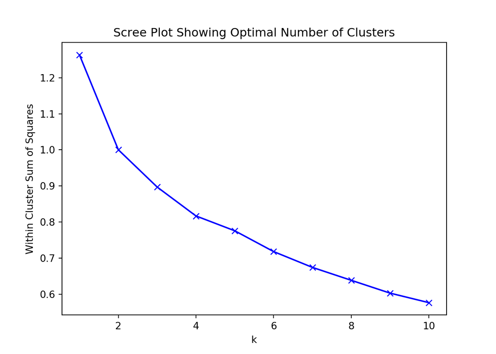

```python
# Initialize total within-cluster sum of squares: wss
wss = []
# Execute algorithm for 1 to 11 cluster centers and record wss
K = range(1, 11)
for k in K:
    kmCandyCluster = KMeans(n_clusters = k, n_init = 30)
    kmCandyCluster.fit(predictors)
    # Save total within sum of squares to wss variable
    wss.append(sum(np.min(cdist(predictors, kmCandyCluster.cluster_centers_, 'euclidean'), \
               axis=1)) / predictors.shape[0])
# Plot total within-cluster sum of squares against number of clusters
plt.plot(K, wss, 'bx-')
plt.xlabel('k')
plt.ylabel('Within Cluster Sum of Squares')
plt.title('Scree Plot Showing Optimal Number of Clusters')
plt.show()
```